# Hot Dagitty Dog!! We finally have a rational way to decide what variables to put in our model

## Outline for today’s class

- Review of confounding
- Directed acylic graphs key concepts
- Development of causal models using web-based dagitty

## Recalling what confounding is and why we adjust for it (or condition on it)?

- An association between an exposure and an outcome that may be explained fully or partially by another variable that is both associated with the exposure and is an independent risk factor (or proxy of an independent risk factor) for the outcome
- From Suttorp et al, “A factor that is associated with the exposure and with the outcome and is not in the causal pathway between the exposure and the outcome” (i.e. not a mediator)
- Ideally, we would do an experiment to determine whether X causes Y by comparing Y (rate, mean, etc) between two groups that differ only by the presence or absence of X. This is only possible in the laboratory. Our closest example in humans are RCTs where we can balance confounding variables between two or more groups through randomization.
- Most of our public health and social work studies are not RCTs though so we typically have to adjust for confounding variables in regression models that may explain any observed relationship between X and Y that is not really due to the causal effect of X on Y but rather due to another variable (Z) that is associated with both X and Y.

## What are DAGs?

- Visual representations of causal assumptions used in determine whether a variable is causally related to an outcome (What is the causal impact of X on Y?)
- Used to determine the **minimal set** of covariates needed to adjust for confounding to get the **total effect** of X on Y. Can also determine mediators that can be adjusted for to get the **direct effect** of X on Y (but we will not cover that in this course)
- DAGs may include both measured and unmeasured variables
- They are acyclic, you can’t get back where you started by following the directions of the arrows

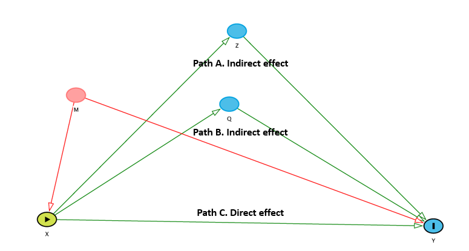

## Why use them?

- In the traditional way of thinking about confounding, we consider confounding by controlling for it one variable at a time
- Using DAGs we consider all variables in a causal model together that can potentially impact an exposure/outcome relationship, which can prevent over and under-adjusting as well as adjusting for mediators and colliders (more later)
- It is considered by many experts in the field to be “state of the art”

## How do we choose variables to include in our DAG?

- Conduct a literature review
- Common sense justifications
- Based on what is available in your dataset

## Let’s look at the example from the Suttorp et al paper

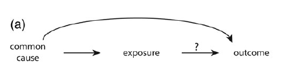

- This is a DAG because in DAGs all variables are connected to one another through arrows
- Arrows represent causal effects of one variable on another (causal pathways)
- You can remove the causal effect of one factor on another if you **block** (aka adjust) the factor causing the effect

## DAG terminology

- A **path** is a sequence of arrows connecting an exposure to an outcome *independent* of the direction of the arrows
- A **directed path** is one where the arrows all point in the same direction (can never form a closed loop), the future cannot cause the past making graphs acyclic (a closed loop would imply the future causes the past)
- It is good practice to start DAGs going from left to right (exposure -> outcome) in order of chronology
- A **common cause** of an exposure and an outcome is the same as a confounder in the traditional sense
- A **backdoor path** indicates the presence of confounding in a DAG and needs to be adjusted for by **blocking** on the **common cause**

## Back to the example

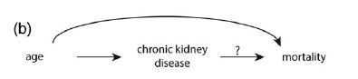

- Age is a **common cause** of both CKD and mortality and is a confounder of the association between CKD and mortality
- The association between age and CKD is a **backdoor path** that needs to be **blocked** in a regression model
- When all potential backdoor paths are identified through DAGs, counfounding is identified

## Ways to control for confounding

- Restriction
- Matching
- Stratification and pooling
- Randomization
- **Multivariate adjustment**
- When we control confounding through any of these methods, we *condition* on a variable (same as adjust for the variable), which is indicated by a box around that variable and that the backdoor path has been blocked/confounding is removed.

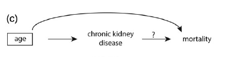

## What is a collider?

- A collider is a variable where two arrows come together
- It automatically blocks a path
- If you condition on a collider it could bias your estimates
- In DAG terminology, a collider is a descendent of both the exposure and the outcome
- **Bottom line**: Don’t condition/adjust on a collider!! Dagitty will identify collider no no’s so you don’t need to worry about it as long as your causal diagram is correct (this can never be known of course)

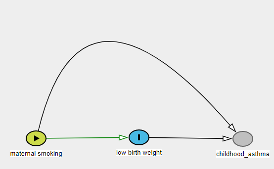

## Steps in making a DAG

1. Identify your exposure and your outcome and draw an arrow between them from exposure to outcome
2. Identify variables that are risk factors for your outcome (through a literature search) and draw an arrow from each risk factor to the outcome
3. Identify how these variables that are risk factors relate to your exposure (do they have a causal effect on your exposure?) and draw an arrow if they do from the risk factor to the exposure
4. Identify whether any of the variables that are risk factors cause another variable that is a risk factor and draw an arrow. This will allow you to identify all **backdoor paths** to determine which variables to condition on/adjust for. **Backdoor paths** connect your outcome to your exposure. If you condition on them you block the path and control for confounding. You only need a single block on the path to block the path. (thanks to Scott Venners, Simon Frasier University)

## Some points to remember

- Single arrows between two variables indicates a complete causal claim
- You don’t have to adjust for risk factors for your outcome that are not related to your exposure or any other variables (besides the outcome)-PARSIMONY!
- Throwing everything in the model can reduce statistical power, cause you to adjust for mediators and colliders, and lead to biased estimates of cause and effect

## Dagitty

- Let’s try making a causal diagram using dagitty http://www.dagitty.net/
- Some dagitty terminology (let’s read for a minute first a play a game)